# Homework 2

## Problem 1

```python
import numpy as np

# Part (a): Smoothing by Bin Means (Bin Depth = 10)

import numpy as np

data = [6, 7, 6, 7, 7, 6, 11, 4, 8, 6, 6, 12, 2, 8, 12, 5, 7, 8, 6, 11,
        6, 8, 9, 11, 5, 9, 8, 9, 8, 12]
print(" Part (a): Smoothing by Bin Means (Bin Depth = 10)\n")
print("STEP 1: Original data (30 values)")
print(data)

print("\nSTEP 2: Sort the data")
sorted_data = sorted(data)
print(sorted_data)

print("\nSTEP 3: Divide into 3 equal-depth bins (10 values each)")
print("Bin 1 (Low days):", sorted_data[0:10])
print("Bin 2 (Medium days):", sorted_data[10:20])
print("Bin 3 (High days):", sorted_data[20:30])

print("\nSTEP 4: Calculate the mean for each bin")
mean1 = np.mean(sorted_data[0:10])
mean2 = np.mean(sorted_data[10:20])
mean3 = np.mean(sorted_data[20:30])

print(f"Bin 1 mean: {mean1}")
print(f"Bin 2 mean: {mean2}")
print(f"Bin 3 mean: {mean3}")

print("\nSTEP 5: Replace each value in each bin with its bin mean")
smoothed_data = []
for i in range(10):
    smoothed_data.append(float(mean1))
for i in range(10):
    smoothed_data.append(float(mean2))
for i in range(10):
    smoothed_data.append(float(mean3))

print("Smoothed data:")
print([f"{x:.1f}" for x in smoothed_data])
```

```
 Part (a): Smoothing by Bin Means (Bin Depth = 10)

STEP 1: Original data (30 values)
[6, 7, 6, 7, 7, 6, 11, 4, 8, 6, 6, 12, 2, 8, 12, 5, 7, 8, 6, 11, 6, 8, 9, 11, 5, 9, 8, 9, 8, 12]

STEP 2: Sort the data
[2, 4, 5, 5, 6, 6, 6, 6, 6, 6, 6, 7, 7, 7, 7, 8, 8, 8, 8, 8, 8, 9, 9, 9, 11, 11, 11, 12, 12, 12]

STEP 3: Divide into 3 equal-depth bins (10 values each)
Bin 1 (Low days): [2, 4, 5, 5, 6, 6, 6, 6, 6, 6]
Bin 2 (Medium days): [6, 7, 7, 7, 7, 8, 8, 8, 8, 8]
Bin 3 (High days): [8, 9, 9, 9, 11, 11, 11, 12, 12, 12]

STEP 4: Calculate the mean for each bin
Bin 1 mean: 5.2
Bin 2 mean: 7.4
Bin 3 mean: 10.4

STEP 5: Replace each value in each bin with its bin mean
Smoothed data:
['5.2', '5.2', '5.2', '5.2', '5.2', '5.2', '5.2', '5.2', '5.2', '5.2', '7.4', '7.4', '7.4', '7.4', '7.4', '7.4', '7.4', '7.4', '7.4', '7.4', '10.4', '10.4', '10.4', '10.4', '10.4', '10.4', '10.4', '10.4', '10.4', '10.4']
```

```python
# Part (b): Smoothing by Bin Medians (Equal Width)

print("STEP 1: Determine bin width")
min_val = 2
max_val = 12
range_val = max_val - min_val
bin_width = range_val / 3

print(f"Range: {max_val} - {min_val} = {range_val}")
print(f"Bin width: {range_val}/3 = {bin_width:.2f}")

print("\nSTEP 2: Create bin ranges")
print(f"Bin 1: [{min_val}, {min_val + bin_width:.2f})")
print(f"Bin 2: [{min_val + bin_width:.2f}, {min_val + 2*bin_width:.2f})")
print(f"Bin 3: [{min_val + 2*bin_width:.2f}, {max_val}]")
print("\nSTEP 3: Assign values to bins and find medians")

bin1_values = [2, 4, 5, 5]
bin2_values = [6, 6, 6, 6, 6, 6, 6, 7, 7, 7, 7, 8, 8, 8, 8, 8, 8]
bin3_values = [9, 9, 9, 11, 11, 11, 12, 12, 12]

median1 = 4.5
median2 = 7
median3 = 11

print(f"Bin 1: {bin1_values} → Median = {median1}")
print(f"Bin 2: {bin2_values} → Median = {median2}")
print(f"Bin 3: {bin3_values} → Median = {median3}")

print("\nSTEP 4: Create smoothed data by replacing with medians")
smoothed_data_b = []
smoothed_data_b.extend([median1] * len(bin1_values))
smoothed_data_b.extend([median2] * len(bin2_values))
smoothed_data_b.extend([median3] * len(bin3_values))

print(f"Smoothed data: {smoothed_data_b}")
```

```
STEP 1: Determine bin width
Range: 12 - 2 = 10
Bin width: 10/3 = 3.33

STEP 2: Create bin ranges
Bin 1: [2, 5.33)
Bin 2: [5.33, 8.67)
Bin 3: [8.67, 12]

STEP 3: Assign values to bins and find medians
Bin 1: [2, 4, 5, 5] → Median = 4.5
Bin 2: [6, 6, 6, 6, 6, 6, 6, 7, 7, 7, 7, 8, 8, 8, 8, 8, 8] → Median = 7
Bin 3: [9, 9, 9, 11, 11, 11, 12, 12, 12] → Median = 11

STEP 4: Create smoothed data by replacing with medians
Smoothed data: [4.5, 4.5, 4.5, 4.5, 7, 7, 7, 7, 7, 7, 7, 7, 7, 7, 7, 7, 7, 7, 7, 7, 7, 11, 11, 11, 11, 11, 11, 11, 11, 11]
```

(c). I would prefer the equal width method with medians because it revealed that 17 out of 30 days (57%) fall into the medium range, which shows that mail delivery typically clusters around 6-8 items rather than being evenly distributed. Additionally, using medians instead of means reduces the impact of outliers like the 2-delivery day, giving us bin representatives (4.5, 7, 11) that better reflect the actual values in each group."For practical planning purposes, knowing that most days are typical (6-8 deliveries) rather than evenly split between low/medium/high allows USPS to optimize staffing for the common scenario while maintaining flexibility for the occasional extreme days.

```python
print("Part (d): Min-Max Normalization\n")

data_min = 2
data_max = 12

value = 5

normalized = (value - data_min) / (data_max - data_min)

print(f"Min-Max Normalization:")
print(f"Original range: [{data_min}, {data_max}]")
print(f"Value to transform: {value}")
print(f"Calculation: ({value} - {data_min}) / ({data_max} - {data_min}) = {normalized}")
print(f"Normalized value: {normalized}")
```

```
Part (d): Min-Max Normalization

Min-Max Normalization:
Original range: [2, 12]
Value to transform: 5
Calculation: (5 - 2) / (12 - 2) = 0.3
Normalized value: 0.3
```

```python
import numpy as np

data = [6, 7, 6, 7, 7, 6, 11, 4, 8, 6, 6, 12, 2, 8, 12, 5, 7, 8, 6, 11,
        6, 8, 9, 11, 5, 9, 8, 9, 8, 12]

mean = np.mean(data)
std = np.std(data, ddof=1)  # ddof=1 for sample standard deviation
print("Part (e)\n")
print(f"Mean: {mean:.2f}")
print(f"Standard deviation: {std:.2f}")
value = 5
z_score = (value - mean) / std
print(f"z-score = {z_score:.2f}", end="")
```

```
Part (e)

Mean: 7.67
Standard deviation: 2.47
z-score = -1.08
```

part (f).

I would prefer min-max normalization for this mail delivery data because it makes for easy communication to non-technical staff. While z-score normalization provides an understanding of the relationship with the standard deviation from the mean for those familiar with statistics, min-max normalization with [0,1] range is universally interpretable. For practical use at USPS, min-max would be more practical since managers can easily understand that a value of 0.3 means 30% of the way from minimum to maximum. This intuitive interpretation makes it better for day-to-day operational decisions.

## Problem 2

```python
import pandas as pd
import numpy as np
import matplotlib.pyplot as plt
import statsmodels.api as sm


from ISLP import load_data

bikeshare = load_data("Bikeshare")


print("Dataset shape:", bikeshare.shape)
print("\nFirst few rows:")
print(bikeshare.head())
print("\nColumn names:")
print(bikeshare.columns.tolist())
```

```
Dataset shape: (8645, 15)

First few rows:
   season mnth  day hr  holiday  weekday  workingday weathersit  temp   atemp  \
0       1  Jan    1  0        0        6           0      clear  0.24  0.2879
1       1  Jan    1  1        0        6           0      clear  0.22  0.2727
2       1  Jan    1  2        0        6           0      clear  0.22  0.2727
3       1  Jan    1  3        0        6           0      clear  0.24  0.2879
4       1  Jan    1  4        0        6           0      clear  0.24  0.2879

    hum  windspeed  casual  registered  bikers
0  0.81        0.0       3          13      16
1  0.80        0.0       8          32      40
2  0.80        0.0       5          27      32
3  0.75        0.0       3          10      13
4  0.75        0.0       0           1       1

Column names:
['season', 'mnth', 'day', 'hr', 'holiday', 'weekday', 'workingday', 'weathersit', 'temp', 'atemp', 'hum', 'windspeed', 'casual', 'registered', 'bikers']
```

```python
import pandas as pd
import numpy as np
import matplotlib.pyplot as plt
import statsmodels.api as sm



X = bikeshare['temp']  # Predictor
y = bikeshare['bikers']  # Response


X_with_intercept = sm.add_constant(X)

model = sm.OLS(y, X_with_intercept).fit()


print("Part (a): Simple Linear Regression\n")
print(model.summary())
```

```
Part (a): Simple Linear Regression

                            OLS Regression Results
==============================================================================
Dep. Variable:                 bikers   R-squared:                       0.204
Model:                            OLS   Adj. R-squared:                  0.204
Method:                 Least Squares   F-statistic:                     2210.
Date:                Wed, 01 Oct 2025   Prob (F-statistic):               0.00
Time:                        20:49:01   Log-Likelihood:                -53611.
No. Observations:                8645   AIC:                         1.072e+05
Df Residuals:                    8643   BIC:                         1.072e+05
Df Model:                           1
Covariance Type:            nonrobust
==============================================================================
                 coef    std err          t      P>|t|      [0.025      0.975]
------------------------------------------------------------------------------
const         -5.3745      3.423     -1.570      0.116     -12.085       1.336
temp         305.0060      6.488     47.008      0.000     292.287     317.725
==============================================================================
Omnibus:                      960.001   Durbin-Watson:                   0.396
Prob(Omnibus):                  0.000   Jarque-Bera (JB):             1327.920
Skew:                           0.885   Prob(JB):                    4.43e-289
Kurtosis:                       3.742   Cond. No.                         6.30
==============================================================================

Notes:
[1] Standard Errors assume that the covariance matrix of the errors is correctly specified.
```

Part (b).

There is a significant association between temperature and bikers because the p-value < 0.05, the typical threshold for statistical significance and the t-statistic of 47.008 is far greater than threshold of 2 which suggests significance.

Part (c).

The R-squared of 0.204 indicates a moderately weak relationship, where about 20.4% of the variation in bikers is explained by temp.

Part (d).

The relationship is positive shown by a positive coefficient for temp of 305.01. This means for every 1-unit increase in temp, the model predicts an increase of about 305 bikers

```python
print("Part (e)\n")

min_temp = bikeshare['temp'].min()
print(f"Minimum Temp: {min_temp}")

Predicted_Bikers = -5.3745 + 305.0060 * 0.02
print(f'Predicted Bikers: {Predicted_Bikers:.2f}')
```

```
Part (e)

Minimum Temp: 0.02
Predicted Bikers: 0.73
```

Part (f).

This model is not appropriate to estimate the number of bikers on a day that averages at minimum temp because the r^2 value is 0.2 or only explains about 20% of the situation and the model produces a prediction of 0.73 bikers which is cannot be a real world number for this situation.

```
Part (g)
```

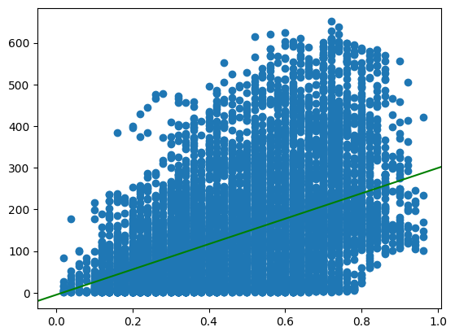

```python
import matplotlib.pyplot as plt
print("Part (g)")
fig, ax = plt.subplots()
plt.scatter(bikeshare.temp, bikeshare.bikers)
ax.axline(xy1=(0, -5.3745), slope=305.0060, color='g')
```

```
Part (h)
```

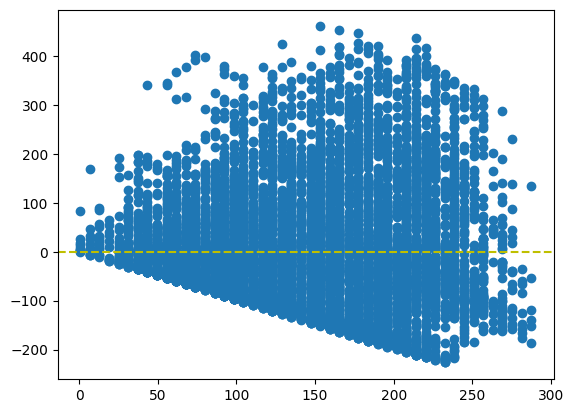

```python
import matplotlib.pyplot as plt

print("Part (h)\n")
X = sm.add_constant(bikeshare.temp)
predicted_bikers = model.predict(X)
residuals = bikeshare.bikers - predicted_bikers

plt.scatter(predicted_bikers, residuals)
plt.axhline(y=0, color='y', linestyle='--')
```

The residual model shows two patterns.

1. An upside-down U-shape, which means the relationship isn't perfectly linear.
2. A widening spread, which means the model's error isn't consistent.

## Problem 3

```python
print("Part (a)\n")
bikeshare['hr'] = pd.to_numeric(bikeshare['hr'])

correlation_matrix = bikeshare.corr(numeric_only=True)

print(correlation_matrix)
```

```
Part (a)

              season       day        hr   holiday   weekday  workingday  \
season      1.000000  0.825218 -0.012179 -0.001116 -0.013639    0.013763
day         0.825218  1.000000 -0.011560  0.030972  0.010990    0.003277
hr         -0.012179 -0.011560  1.000000 -0.000929 -0.005618    0.003792
holiday    -0.001116  0.030972 -0.000929  1.000000 -0.076324   -0.247934
weekday    -0.013639  0.010990 -0.005618 -0.076324  1.000000    0.018572
workingday  0.013763  0.003277  0.003792 -0.247934  0.018572    1.000000
temp        0.343535  0.261316  0.120548 -0.020059 -0.038969    0.053405
atemp       0.351910  0.273091  0.116382 -0.026915 -0.042439    0.052551
hum         0.191793  0.189453 -0.251188 -0.022895 -0.051307    0.025305
windspeed  -0.154735 -0.154169  0.125153  0.000502  0.039586    0.010509
casual      0.141894  0.090982  0.303720  0.052906 -0.013475   -0.324750
registered  0.220666  0.185044  0.390313 -0.046779 -0.000500    0.129540
bikers      0.221719  0.177797  0.407486 -0.022912 -0.004321    0.011704

                temp     atemp       hum  windspeed    casual  registered  \
season      0.343535  0.351910  0.191793  -0.154735  0.141894    0.220666
day         0.261316  0.273091  0.189453  -0.154169  0.090982    0.185044
hr          0.120548  0.116382 -0.251188   0.125153  0.303720    0.390313
holiday    -0.020059 -0.026915 -0.022895   0.000502  0.052906   -0.046779
weekday    -0.038969 -0.042439 -0.051307   0.039586 -0.013475   -0.000500
workingday  0.053405  0.052551  0.025305   0.010509 -0.324750    0.129540
temp        1.000000  0.992022 -0.039525  -0.005989  0.478931    0.381614
atemp       0.992022  1.000000 -0.023541  -0.046120  0.473859    0.378275
hum        -0.039525 -0.023541  1.000000  -0.263196 -0.307096   -0.243815
windspeed  -0.005989 -0.046120 -0.263196   1.000000  0.066113    0.080874
casual      0.478931  0.473859 -0.307096   0.066113  1.000000    0.518816
registered  0.381614  0.378275 -0.243815   0.080874  0.518816    1.000000
bikers      0.451233  0.447029 -0.288615   0.085356  0.714742    0.968717

              bikers
season      0.221719
day         0.177797
hr          0.407486
holiday    -0.022912
weekday    -0.004321
workingday  0.011704
temp        0.451233
atemp       0.447029
hum        -0.288615
windspeed   0.085356
casual      0.714742
registered  0.968717
bikers      1.000000
```

```
Part (b)
```

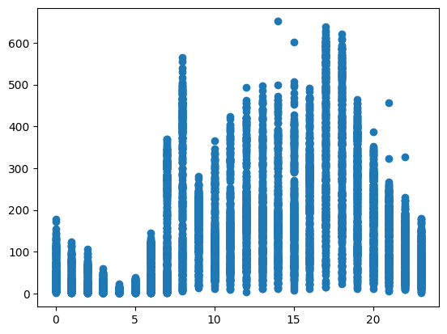

```python
print("Part (b)\n")

plt.scatter(bikeshare.hr, bikeshare.bikers)
```

```python
print("Part (c)\n")

X = sm.add_constant(bikeshare['hr'])
y = bikeshare['bikers']


model_hr = sm.OLS(y, X).fit()


print(model_hr.summary())


print(f"MSE: {model_hr.mse_resid}")
```

```
Part (c)

                            OLS Regression Results
==============================================================================
Dep. Variable:                 bikers   R-squared:                       0.166
Model:                            OLS   Adj. R-squared:                  0.166
Method:                 Least Squares   F-statistic:                     1721.
Date:                Wed, 01 Oct 2025   Prob (F-statistic):               0.00
Time:                        22:51:48   Log-Likelihood:                -53810.
No. Observations:                8645   AIC:                         1.076e+05
Df Residuals:                    8643   BIC:                         1.076e+05
Df Model:                           1
Covariance Type:            nonrobust
==============================================================================
                 coef    std err          t      P>|t|      [0.025      0.975]
------------------------------------------------------------------------------
const         52.4482      2.564     20.453      0.000      47.421      57.475
hr             7.8926      0.190     41.483      0.000       7.520       8.266
==============================================================================
Omnibus:                     1401.800   Durbin-Watson:                   0.452
Prob(Omnibus):                  0.000   Jarque-Bera (JB):             2245.028
Skew:                           1.117   Prob(JB):                         0.00
Kurtosis:                       4.115   Cond. No.                         26.4
==============================================================================

Notes:
[1] Standard Errors assume that the covariance matrix of the errors is correctly specified.
MSE: 14931.07657670644
```

```python
print("Part (d)\n")
bikeshare['hr_sq'] = bikeshare['hr']**2


X = sm.add_constant(bikeshare[['hr', 'hr_sq']])
y = bikeshare['bikers']


model_hr_sq = sm.OLS(y, X).fit()

print(model_hr_sq.summary())
print(f"MSE: {model_hr_sq.mse_resid}")
```

```
Part (d)

                            OLS Regression Results
==============================================================================
Dep. Variable:                 bikers   R-squared:                       0.305
Model:                            OLS   Adj. R-squared:                  0.305
Method:                 Least Squares   F-statistic:                     1898.
Date:                Wed, 01 Oct 2025   Prob (F-statistic):               0.00
Time:                        22:56:02   Log-Likelihood:                -53021.
No. Observations:                8645   AIC:                         1.060e+05
Df Residuals:                    8642   BIC:                         1.061e+05
Df Model:                           2
Covariance Type:            nonrobust
==============================================================================
                 coef    std err          t      P>|t|      [0.025      0.975]
------------------------------------------------------------------------------
const        -46.4378      3.336    -13.918      0.000     -52.978     -39.898
hr            34.7187      0.668     51.980      0.000      33.409      36.028
hr_sq         -1.1647      0.028    -41.594      0.000      -1.220      -1.110
==============================================================================
Omnibus:                     1424.199   Durbin-Watson:                   0.530
Prob(Omnibus):                  0.000   Jarque-Bera (JB):             2308.210
Skew:                           1.123   Prob(JB):                         0.00
Kurtosis:                       4.166   Cond. No.                         693.
==============================================================================

Notes:
[1] Standard Errors assume that the covariance matrix of the errors is correctly specified.
MSE: 12442.03847579621
```

```python
print("Part (e)\n")
bikeshare['hr_workingday'] = bikeshare['hr'] * bikeshare['workingday']

# Prepare the variables for the new model
predictors = ['hr', 'hr_sq', 'workingday', 'hr_workingday']
X = sm.add_constant(bikeshare[predictors])
y = bikeshare['bikers']

# Fit the new model
model_int = sm.OLS(y, X).fit()

# Print the summary and MSE
print(model_int.summary())
print(f"MSE: {model_int.mse_resid}")
```

```
Part (e)

                            OLS Regression Results
==============================================================================
Dep. Variable:                 bikers   R-squared:                       0.306
Model:                            OLS   Adj. R-squared:                  0.305
Method:                 Least Squares   F-statistic:                     950.8
Date:                Wed, 01 Oct 2025   Prob (F-statistic):               0.00
Time:                        22:57:15   Log-Likelihood:                -53018.
No. Observations:                8645   AIC:                         1.060e+05
Df Residuals:                    8640   BIC:                         1.061e+05
Df Model:                           4
Covariance Type:            nonrobust
=================================================================================
                    coef    std err          t      P>|t|      [0.025      0.975]
---------------------------------------------------------------------------------
const           -41.9017      4.777     -8.771      0.000     -51.266     -32.537
hr               34.1591      0.714     47.835      0.000      32.759      35.559
hr_sq            -1.1649      0.028    -41.610      0.000      -1.220      -1.110
workingday       -6.6632      5.025     -1.326      0.185     -16.514       3.188
hr_workingday     0.8237      0.373      2.206      0.027       0.092       1.556
==============================================================================
Omnibus:                     1404.118   Durbin-Watson:                   0.530
Prob(Omnibus):                  0.000   Jarque-Bera (JB):             2253.647
Skew:                           1.117   Prob(JB):                         0.00
Kurtosis:                       4.127   Cond. No.                     1.32e+03
==============================================================================

Notes:
[1] Standard Errors assume that the covariance matrix of the errors is correctly specified.
[2] The condition number is large, 1.32e+03. This might indicate that there are
strong multicollinearity or other numerical problems.
MSE: 12436.149750215758
```

```python
print("Part (f)\n")

predictors = ['hr', 'hr_sq', 'workingday', 'hr_workingday', 'temp']
X = sm.add_constant(bikeshare[predictors])
y = bikeshare['bikers']

model_final = sm.OLS(y, X).fit()

print(model_final.summary())
print(f"MSE: {model_final.mse_resid}")
```

```
Part (f)

                            OLS Regression Results
==============================================================================
Dep. Variable:                 bikers   R-squared:                       0.441
Model:                            OLS   Adj. R-squared:                  0.440
Method:                 Least Squares   F-statistic:                     1362.
Date:                Wed, 01 Oct 2025   Prob (F-statistic):               0.00
Time:                        23:12:31   Log-Likelihood:                -52083.
No. Observations:                8645   AIC:                         1.042e+05
Df Residuals:                    8639   BIC:                         1.042e+05
Df Model:                           5
Covariance Type:            nonrobust
=================================================================================
                    coef    std err          t      P>|t|      [0.025      0.975]
---------------------------------------------------------------------------------
const          -139.8046      4.793    -29.170      0.000    -149.200    -130.410
hr               30.3688      0.646     46.994      0.000      29.102      31.636
hr_sq            -1.0420      0.025    -41.234      0.000      -1.091      -0.992
workingday      -13.8377      4.513     -3.066      0.002     -22.684      -4.992
hr_workingday     0.9535      0.335      2.846      0.004       0.297       1.610
temp            252.1313      5.518     45.696      0.000     241.315     262.947
==============================================================================
Omnibus:                     1384.526   Durbin-Watson:                   0.630
Prob(Omnibus):                  0.000   Jarque-Bera (JB):             2279.934
Skew:                           1.078   Prob(JB):                         0.00
Kurtosis:                       4.296   Cond. No.                     1.48e+03
==============================================================================

Notes:
[1] Standard Errors assume that the covariance matrix of the errors is correctly specified.
[2] The condition number is large, 1.48e+03. This might indicate that there are
strong multicollinearity or other numerical problems.
MSE: 10016.530813485826
```

Part (g).

The MSE on the training data will decrease because it is effectively overfitting the model.

Part (h).

I would expect the final model to have the best performance. Each predictor we added allowed the model to better capture the complex, non-linear patterns in the data. This is confirmed by the fact that this model had the highest R-squared and the lowest MSE, indicating it is the most accurate and reliable of the models we built.